# Landsat bricks for SITS

Alber Sánchez

2019-06-15

# Data bricks for sits

Analysing massive datasets of satellite imagery is hard. Even when using a single data source, handling thousand of images is a time consuming task. In order to ease data management and increase computing performance, we use a data cube. A data cube is a set of large computer files of homogeneous spatial, temporal, and spectral properties.

Our data cube is organized into chunks of spatio-temporal data that we call bricks. Each brick stores one year of data of a single band (or remote sensing index) of the same region using any image format. The data sources for our bricks are the Landsat and MODIS satellite programs.

The Landsat program has continually provided imagery of the Earth surface for 45 years and it is a long-term program for studying changes in Earth’s global environment. The most recent mission (Landsat-8) provides visible and thermal images of the landmasses on Earth each two weeks at 30m resolution (Roy et al. 2014; Irons, Dwyer, and Barsi 2012).

On the other hand, the MODIS are satellite sensors record 36 spectral bands and produce images every two days. Both Landsat-8 and MODIS enable scientists to compare and monitor global vegetation parameters such as photosynthetic activity and phenological change.

## MODIS bricks

For our MODIS bricks, we used two products derived from MODIS, known as MOD13Q1(Didan 2015a) and MYD13Q1(Didan 2015b). Both are used for land use and cover chage analysis. These products havethe same spatial resolution of 250m and their images are composites of the best pixel of two weeks. The imagery dates back to 2000 (Friedl et al. 2002).

## Landsat 8 bricks

A brick construction starts with the raw images taken by the Landsat program. Specifically, we use Landsat-8 images which undergo radiometric and geometric corrections to compensate for topographic (e.g. relief) and atmospheric phenomena (e.g. aerosols). The results are known as surface reflectance images, which relate image pixels to precise locations on Earth (Barsi et al. 2014). This surfaace reflectance pre-processing process is made on demand by the Geological Service of the United States of America.

### Interpolated bricks

We fill the cloud/shadows gaps in the Landsat-8 images using MOD13Q1/MYD13Q1 data products. To compensate for the differences in resolution and to keep the Landsat-8 structure of the data, we apply a bilinear interpolation. Finally, we stacked each band or vegetation index into a independent raster file. This procedures is summarized in the Figure below.

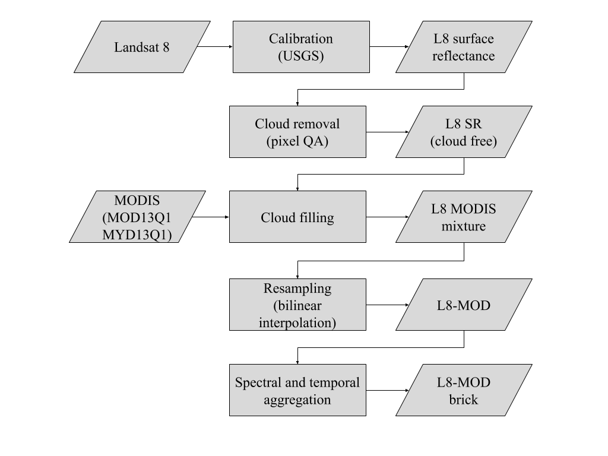

Workflow of interpolated bricks.

### StarFM bricks

The StarFM fusion model was first described in (Gao et al. 2006). The model provides a way to build fine from fine and coarse resolution images. The fusion model use a fine-coarse image pair to build a statistical model to be applied to a coarse resolution image of a differnte date. The results is a fine resolution image.

We employed StarFM to fill in the clouds of Landsat 8 images. We build StarFM models using fine-coarse pairs at future times (T1) to fill in the cloud gaps of fine resolution images (T0) (see image below).

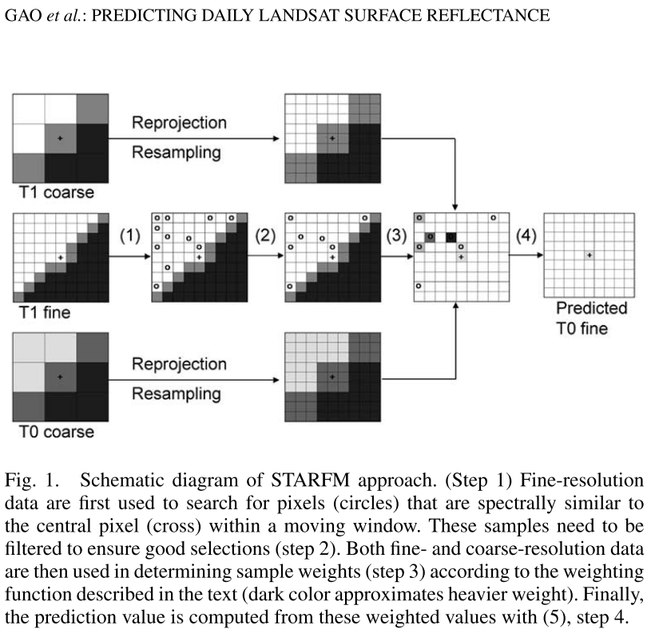

Fusion model schema. Source: (Gao et al. 2006)

The [StarFM software](https://www.ars.usda.gov/research/software/download/?softwareid=432) is available at the Departmen of Agriculture of the United States of America.

StarFM is reference to other fusion models such as ESTARFM (Zhu et al. 2010), and STAARCH (Hilker et al. 2009), and STRUM (Gevaert and García-Haro 2015). See (Gao et al. 2015) for futher details.

### Few cloud bricks

The aforementioned bricks were produced for agricultural years (from August to July) using the images available (23) and also using the images with the fewer clouds.

# References

Barsi, Julia A., Kenton Lee, Geir Kvaran, Brian L. Markham, and Jeffrey A. Pedelty. 2014. “The spectral response of the Landsat-8 operational land imager.” *Remote Sensing* 6 (10): 10232–51. doi:10.3390/rs61010232.

Didan, Kamel. 2015a. “MOD13Q1 MODIS/Terra Vegetation Indices 16-Day L3 Global 250m SIN Grid V006.” Data set. NASA EOSDIS LP DAAC. doi:10.5067/MODIS/MOD13Q1.006.

———. 2015b. “MYD13Q1 MODIS/Aqua Vegetation Indices 16-Day L3 Global 250m SIN Grid V006.” Data set. NASA EOSDIS LP DAAC. doi:10.5067/MODIS/MYD13Q1.006.

Friedl, M.A, D.K McIver, J.C.F Hodges, X.Y Zhang, D Muchoney, A.H Strahler, C.E Woodcock, et al. 2002. “Global land cover mapping from MODIS: algorithms and early results.” *Remote Sensing of Environment* 83 (1-2): 287–302. doi:10.1016/S0034-4257(02)00078-0.

Gao, Feng, Thomas Hilker, Xiaolin Zhu, Martha Anderson, Jeffrey Masek, Peijuan Wang, and Yun Yang. 2015. “Fusing Landsat and MODIS Data for Vegetation Monitoring.” *IEEE Geoscience and Remote Sensing Magazine* 3 (3): 47–60. doi:10.1109/MGRS.2015.2434351.

Gao, Feng, Jeff Masek, Matt Schwaller, and Forrest Hall. 2006. “On the Blending of the MODIS and Landsat ETM + Surface Reflectance.” *IEEE Transactions on Geoscience and Remote Sensing* 44 (8): 2207–18.

Gevaert, Caroline M., and F. Javier García-Haro. 2015. “A comparison of STARFM and an unmixing-based algorithm for Landsat and MODIS data fusion.” *Remote Sensing of Environment* 156 (January). Elsevier Inc.: 34–44. doi:10.1016/j.rse.2014.09.012.

Hilker, Thomas, Michael A. Wulder, Nicholas C. Coops, Julia Linke, Greg McDermid, Jeffrey G. Masek, Feng Gao, and Joanne C. White. 2009. “A new data fusion model for high spatial- and temporal-resolution mapping of forest disturbance based on Landsat and MODIS.” *Remote Sensing of Environment* 113 (8). Elsevier Inc.: 1613–27. doi:10.1016/j.rse.2009.03.007.

Irons, James R., John L. Dwyer, and Julia A. Barsi. 2012. “The next Landsat satellite: The Landsat Data Continuity Mission.” *Remote Sensing of Environment* 122 (July). Elsevier B.V.: 11–21. doi:10.1016/j.rse.2011.08.026.

Roy, D.P., M.A. Wulder, T.R. Loveland, Woodcock C.E., R.G. Allen, M.C. Anderson, D. Helder, et al. 2014. “Landsat-8: Science and product vision for terrestrial global change research.” *Remote Sensing of Environment* 145 (April). Elsevier B.V.: 154–72. doi:10.1016/j.rse.2014.02.001.

Zhu, Xiaolin, Jin Chen, Feng Gao, Xuehong Chen, and Jeffrey G. Masek. 2010. “An enhanced spatial and temporal adaptive reflectance fusion model for complex heterogeneous regions.” *Remote Sensing of Environment* 114 (11). Elsevier Inc.: 2610–23. doi:10.1016/j.rse.2010.05.032.